# Chapter 10 - Dimension Reduction - Principal Component Regression

The idea of principal component regression is to perform a linear (or other) regression using the PCs of a principal component analysis instead of the original variables. The advantage of such an analysis is of course the reduction of the dimension of the predictors, but it also avoids collinearity problems since the PCs are independent variables.

### Data

In this exercise, we will use a dataset that combines socioeconomic data from the 1990 U.S. Census, law enforcement data from the 1990 U.S. LEMAS survey, and crime data from the 1995 FBI UCR. The variable we seek to predict is the number of crimes per capita. The data is found in the `crimeData` object available in the `mogavs` library. The dataset contains 122 predictor variables gathering socio-economic, crime and police data, whose description can be found here: http://archive.ics.uci.edu/ml/datasets/Communities+and+Crime. The dataset is collected on 1994 large cities in the United States.

The dependent variable is named `y`. Here is the code to access the data and create a training and validation dataset:

```r
library(mogavs)
head(crimeData)
```

```
##   x.V6 x.V7 x.V8 x.V9 x.V10 x.V11 x.V12 x.V13 x.V14 x.V15 x.V16 x.V17 x.V18
## 1 0.19 0.33 0.02 0.90  0.12  0.17  0.34  0.47  0.29  0.32  0.20   1.0  0.37
## 2 0.00 0.16 0.12 0.74  0.45  0.07  0.26  0.59  0.35  0.27  0.02   1.0  0.31
## 3 0.00 0.42 0.49 0.56  0.17  0.04  0.39  0.47  0.28  0.32  0.00   0.0  0.30
## 4 0.04 0.77 1.00 0.08  0.12  0.10  0.51  0.50  0.34  0.21  0.06   1.0  0.58
## 5 0.01 0.55 0.02 0.95  0.09  0.05  0.38  0.38  0.23  0.36  0.02   0.9  0.50
## 6 0.02 0.28 0.06 0.54  1.00  0.25  0.31  0.48  0.27  0.37  0.04   1.0  0.52
##   x.V19 x.V20 x.V21 x.V22 x.V23 x.V24 x.V25 x.V26 x.V27 x.V28         x.V29
## 1  0.72  0.34  0.60  0.29  0.15  0.43  0.39  0.40  0.39  0.32  2.700000e-01
## 2  0.72  0.11  0.45  0.25  0.29  0.39  0.29  0.37  0.38  0.33  1.600000e-01
## 3  0.58  0.19  0.39  0.38  0.40  0.84  0.28  0.27  0.29  0.27  7.000000e-02
## 4  0.89  0.21  0.43  0.36  0.20  0.82  0.51  0.36  0.40  0.39  1.600000e-01
## 5  0.72  0.16  0.68  0.44  0.11  0.71  0.46  0.43  0.41  0.28 -2.775558e-17
## 6  0.68  0.20  0.61  0.28  0.15  0.25  0.62  0.72  0.76  0.77  2.800000e-01
##   x.V30 x.V31 x.V32 x.V33 x.V34 x.V35 x.V36 x.V37 x.V38 x.V39 x.V40 x.V41 x.V42
```

[output cut: 69 more lines]

```r
dim(crimeData)
```

```
## [1] 1994  123
```

```r
set.seed(60603)
id=sample(1:nrow(crimeData))
mydata.train=crimeData[id[1:1450],]
mydata.valid=crimeData[id[1451:nrow(crimeData)],]

# Creation of a dataset without y to do the PCA only on the x
mydata.pca=mydata.train[,-123]
```

Let’s look at the correlation structure of the data. In the case of high dimensions, this can be visualized with the help of a correlation graph:

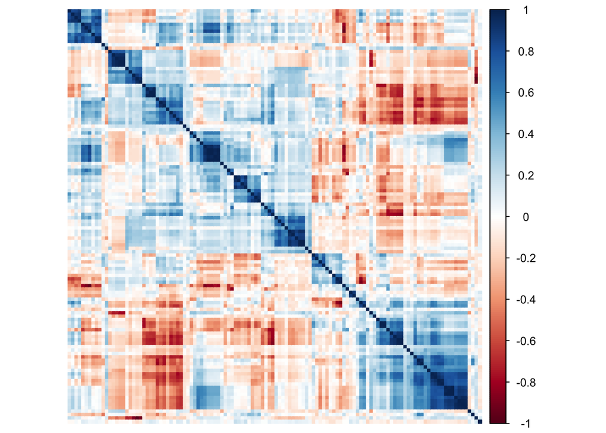

```r
library(corrplot)
correl= cor(mydata.pca, method="pearson")
corrplot(correl, method= "color", order = "hclust",tl.pos = 'n')
```

The `corrplot` function has several interesting options that allow us, among other things, to order the variables on the graph by groups of variables that are most correlated with each other. This graph allows us to see that there is a certain correlation pattern in the variables.

When the variables have very different variances from each other caused by the unit of measurement of these variables, it is important to normalize the data before performing a PCA. Let’s look at this here:

```r
summary(diag(var(mydata.pca)))
```

```
##     Min.  1st Qu.   Median     Mean  3rd Qu.     Max.
## 0.008175 0.030694 0.040937 0.046897 0.052054 0.325591
```

We can see here that the variance can vary by a factor of 40 (mariance-max / variance-min) between variables and therefore it is more prudent to normalize the data. This can be done with the `scale` function, or simply with the `center` and `scale` options of the `prcomp` function. Here is the function that allows you to do a PCA on the data:

```r
# Data normalization
mydata.pca=data.frame(apply(mydata.pca,2,scale))
mydata.train=data.frame(apply(mydata.train,2,scale))
mydata.valid=data.frame(apply(mydata.valid,2,scale))
```

## PCA analysis

We will now perform a principal component analysis on the data.

```r
# PCA Analysiz
result.pca=prcomp(mydata.pca, center=TRUE, scale.=TRUE)

# Display the first 6 rows of the PC matrix for the first 10 PCs
dim(result.pca$x)
```

```
## [1] 1450  122
```

```r
head(result.pca$x[,1:10])
```

```
##              PC1       PC2        PC3         PC4        PC5         PC6
## [1,] -7.73401331 -2.919797  6.6641080 -0.04051131 -0.9796894  4.56416574
## [2,]  3.88312083  5.932372  1.5821356 -2.59266938 -0.1423397  3.44950724
## [3,] -2.15145235  4.961284 -0.6334321 -4.44780545 -2.5489736 -0.04860635
## [4,] -4.77255534  1.311262 -1.3980591 -3.12293525  6.2439825 -0.52301643
## [5,] -0.51759801  3.039726 -2.1448727 -0.71089841  0.1210862 -1.35273315
## [6,]  0.08343564  1.088849 -1.6225413  2.99476897  5.3129154 -0.83249599
##             PC7        PC8        PC9       PC10
## [1,] -0.8075106  3.9415141  1.4564505 -1.6084761
## [2,]  2.8135918  0.4508662  2.7863134 -1.3511917
## [3,] -0.5792541 -2.0950565  0.3409133 -0.2548741
## [4,]  1.6784219  1.4292074 -0.7439334  1.9852077
## [5,] -2.1501838 -1.2055554 -1.0028200  0.8326510
## [6,] -2.9208266  2.3231209 -0.7058230  0.9230135
```

We can see that the PCs are not correlated:

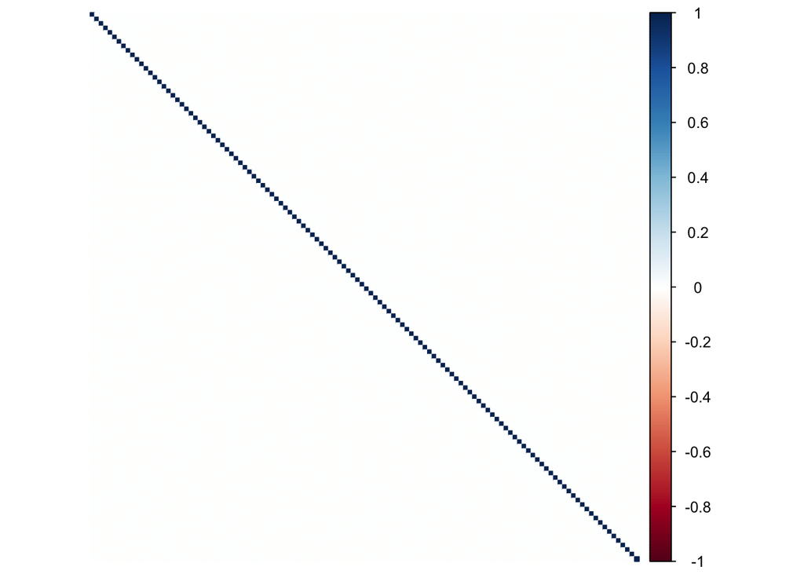

```r
res=cor(result.pca$x, method="pearson")
corrplot(res, method= "color", order = "hclust", tl.pos = 'n')
```

We can also see the proportion of cumulative variance explained by the PCs with the following controls and graph:

```r
summary(result.pca)$importance
```

```
##                            PC1      PC2     PC3      PC4      PC5     PC6
## Standard deviation     5.11294 4.337552 3.11012 2.896465 2.540126 2.44112
## Proportion of Variance 0.21428 0.154220 0.07929 0.068770 0.052890 0.04884
## Cumulative Proportion  0.21428 0.368500 0.44778 0.516550 0.569440 0.61828
##                             PC7      PC8     PC9     PC10     PC11     PC12
## Standard deviation     2.110491 1.945247 1.79601 1.561747 1.468228 1.341199
## Proportion of Variance 0.036510 0.031020 0.02644 0.019990 0.017670 0.014740
## Cumulative Proportion  0.654790 0.685810 0.71225 0.732240 0.749910 0.764650
##                            PC13     PC14     PC15     PC16     PC17     PC18
## Standard deviation     1.328215 1.273075 1.234649 1.172282 1.128705 1.076157
## Proportion of Variance 0.014460 0.013280 0.012490 0.011260 0.010440 0.009490
## Cumulative Proportion  0.779110 0.792400 0.804890 0.816160 0.826600 0.836090
##                            PC19     PC20      PC21      PC22      PC23
## Standard deviation     1.037155 1.013533 0.9720281 0.9304446 0.9018531
## Proportion of Variance 0.008820 0.008420 0.0077400 0.0071000 0.0066700
## Cumulative Proportion  0.844910 0.853330 0.8610700 0.8681700 0.8748400
##                             PC24      PC25      PC26     PC27      PC28
## Standard deviation     0.8947514 0.8610014 0.8454185 0.838982 0.7939846
## Proportion of Variance 0.0065600 0.0060800 0.0058600 0.005770 0.0051700
## Cumulative Proportion  0.8814000 0.8874700 0.8933300 0.899100 0.9042700
##                             PC29      PC30      PC31     PC32      PC33
## Standard deviation     0.7808963 0.7436352 0.7233516 0.717616 0.6926146
## Proportion of Variance 0.0050000 0.0045300 0.0042900 0.004220 0.0039300
## Cumulative Proportion  0.9092700 0.9138000 0.9180900 0.922310 0.9262400
##                             PC34      PC35    PC36     PC37      PC38      PC39
## Standard deviation     0.6743025 0.6644283 0.63944 0.623909 0.6210211 0.5879983
## Proportion of Variance 0.0037300 0.0036200 0.00335 0.003190 0.0031600 0.0028300
## Cumulative Proportion  0.9299700 0.9335900 0.93694 0.940130 0.9432900 0.9461300
##                             PC40      PC41      PC42      PC43     PC44
## Standard deviation     0.5798899 0.5615115 0.5598881 0.5457533 0.527362
## Proportion of Variance 0.0027600 0.0025800 0.0025700 0.0024400 0.002280
## Cumulative Proportion  0.9488800 0.9514700 0.9540400 0.9564800 0.958760
##                             PC45      PC46      PC47      PC48      PC49
## Standard deviation     0.5255461 0.4992748 0.4912256 0.4724824 0.4625158
## Proportion of Variance 0.0022600 0.0020400 0.0019800 0.0018300 0.0017500
## Cumulative Proportion  0.9610200 0.9630600 0.9650400 0.9668700 0.9686300
##                             PC50      PC51      PC52      PC53      PC54
## Standard deviation     0.4572377 0.4483684 0.4387777 0.4257559 0.4108685
## Proportion of Variance 0.0017100 0.0016500 0.0015800 0.0014900 0.0013800
## Cumulative Proportion  0.9703400 0.9719900 0.9735600 0.9750500 0.9764300
```

[output cut: 41 more lines]

```
## Standard deviation     0.07214201 0.06925623 0.06209736 0.05930688 0.05363136
## Proportion of Variance 0.00004000 0.00004000 0.00003000 0.00003000 0.00002000
## Cumulative Proportion  0.99975000 0.99979000 0.99982000 0.99985000 0.99987000
##                             PC111      PC112      PC113      PC114      PC115
## Standard deviation     0.05281263 0.04858919 0.04634033 0.04140026 0.03915503
## Proportion of Variance 0.00002000 0.00002000 0.00002000 0.00001000 0.00001000
## Cumulative Proportion  0.99989000 0.99991000 0.99993000 0.99994000 0.99996000
##                             PC116      PC117      PC118      PC119     PC120
## Standard deviation     0.03840386 0.03478937 0.02903903 0.02604709 0.0239684
## Proportion of Variance 0.00001000 0.00001000 0.00001000 0.00001000 0.0000000
## Cumulative Proportion  0.99997000 0.99998000 0.99999000 0.99999000 1.0000000
##                             PC121       PC122
## Standard deviation     0.02219582 0.000882439
## Proportion of Variance 0.00000000 0.000000000
## Cumulative Proportion  1.00000000 1.000000000
```

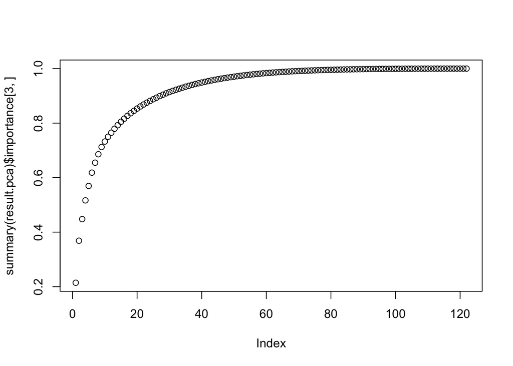

```r
plot(summary(result.pca)$importance[3,])
```

We can see that with a few PCs (between 20 and 30), we manage to explain more than 80% of the variance of the 122 original variables.

We will now fit several regression models and see the differences in the results:

- A linear regression with all the original variables
- A linear regression with all the PCs
- A linear regression with only a subset of the PCs that explain a large percentage of the variance.

### Regression model including all variables

Let’s start with a regression model containing all the original variables

```r
model0=lm(y~.,data=mydata.train)
summary(model0)
```

```
##
## Call:
## lm(formula = y ~ ., data = mydata.train)
##
## Residuals:
##     Min      1Q  Median      3Q     Max
## -2.2395 -0.2950 -0.0511  0.2161  3.2649
##
## Coefficients:
##               Estimate Std. Error t value Pr(>|t|)
## (Intercept) -1.008e-15  1.467e-02   0.000  1.00000
## x.V6         8.922e-02  3.032e-01   0.294  0.76863
## x.V7         1.239e-02  1.064e-01   0.116  0.90734
## x.V8         2.010e-01  7.408e-02   2.713  0.00675 **
## x.V9         2.228e-02  9.984e-02   0.223  0.82341
## x.V10        1.960e-02  4.356e-02   0.450  0.65284
## x.V11        6.397e-02  7.625e-02   0.839  0.40163
## x.V12        1.712e-01  1.124e-01   1.523  0.12794
## x.V13       -1.215e-01  1.359e-01  -0.894  0.37148
## x.V14       -2.967e-01  1.967e-01  -1.509  0.13165
## x.V15        1.951e-01  1.276e-01   1.529  0.12638
## x.V16       -1.625e-01  3.037e-01  -0.535  0.59272
## x.V17        1.139e-01  6.752e-02   1.687  0.09181 .
## x.V18       -5.475e-02  2.292e-01  -0.239  0.81120
## x.V19        6.944e-02  1.230e-01   0.565  0.57246
## x.V20        5.879e-02  3.273e-02   1.797  0.07263 .
## x.V21       -1.714e-01  7.220e-02  -2.375  0.01770 *
## x.V22        1.484e-02  1.173e-01   0.127  0.89933
## x.V23        3.218e-02  6.506e-02   0.495  0.62092
## x.V24       -1.828e-02  3.962e-02  -0.461  0.64460
## x.V25        2.164e-01  1.805e-01   1.199  0.23090
## x.V26        7.548e-02  2.067e-01   0.365  0.71501
## x.V27       -3.189e-01  1.575e-01  -2.025  0.04311 *
## x.V28       -9.413e-03  4.136e-02  -0.228  0.82000
## x.V29       -4.714e-02  1.982e-02  -2.379  0.01752 *
## x.V30        5.642e-02  2.425e-02   2.327  0.02014 *
## x.V31        2.493e-02  1.793e-02   1.390  0.16467
## x.V32        7.219e-03  2.481e-02   0.291  0.77109
## x.V33        1.127e-01  9.282e-02   1.214  0.22482
## x.V34        2.659e-02  9.917e-02   0.268  0.78864
```

[output cut: 84 more lines]

```
## x.V119       1.023e-02  2.792e-02   0.366  0.71420
## x.V120      -1.366e-02  3.453e-02  -0.396  0.69246
## x.V121      -6.128e-02  2.922e-02  -2.098  0.03613 *
## x.V122       1.683e-02  4.699e-02   0.358  0.72028
## x.V123       3.414e-01  1.062e-01   3.213  0.00135 **
## x.V124      -2.747e-02  6.377e-02  -0.431  0.66675
## x.V125      -6.398e-03  2.820e-02  -0.227  0.82057
## x.V126       1.690e-02  2.444e-02   0.692  0.48934
## x.V127      -1.659e-01  1.246e-01  -1.332  0.18306
## ---
## Signif. codes:  0 '***' 0.001 '**' 0.01 '*' 0.05 '.' 0.1 ' ' 1
##
## Residual standard error: 0.5585 on 1327 degrees of freedom
## Multiple R-squared:  0.7143, Adjusted R-squared:  0.6881
## F-statistic:  27.2 on 122 and 1327 DF,  p-value: < 2.2e-16
```

```r
r2_0=summary(model0)$r.squared
r2_0
```

```
## [1] 0.7143362
```

```r
# Calculation of the MSE on the training sample
pred0.train=predict(model0,newdata=mydata.train)
MSE.train0=sqrt(mean((mydata.train$y-pred0.train)^2))
MSE.train0
```

```
## [1] 0.534291
```

```r
# Calculation of the MSE on the validation sample
pred0.valid=predict(model0,newdata=mydata.valid)
MSE.valid0=sqrt(mean((mydata.valid$y-pred0.valid)^2))
MSE.valid0
```

```
## [1] 0.6182843
```

### Regression model including all PCs

Now let’s try to fit the same model, but using all 122 PCs instead of the original 122 variables.

```r
mydata.pc.train=data.frame(result.pca$x,y=mydata.train$y)
model1=lm(y~.,data=mydata.pc.train)
summary(model1)
```

```
##
## Call:
## lm(formula = y ~ ., data = mydata.pc.train)
##
## Residuals:
##     Min      1Q  Median      3Q     Max
## -2.2395 -0.2950 -0.0511  0.2161  3.2649
##
## Coefficients:
##               Estimate Std. Error t value Pr(>|t|)
## (Intercept) -1.969e-16  1.467e-02   0.000 1.000000
## PC1          1.202e-01  2.870e-03  41.903  < 2e-16 ***
## PC2         -7.479e-02  3.383e-03 -22.111  < 2e-16 ***
## PC3          6.063e-02  4.718e-03  12.853  < 2e-16 ***
## PC4         -4.869e-02  5.066e-03  -9.611  < 2e-16 ***
## PC5         -5.117e-02  5.776e-03  -8.858  < 2e-16 ***
## PC6         -3.582e-02  6.010e-03  -5.959 3.24e-09 ***
## PC7          3.393e-02  6.952e-03   4.881 1.18e-06 ***
## PC8          1.344e-01  7.543e-03  17.813  < 2e-16 ***
## PC9          9.413e-03  8.169e-03   1.152 0.249409
## PC10        -3.061e-02  9.395e-03  -3.259 0.001148 **
## PC11        -3.976e-02  9.993e-03  -3.979 7.31e-05 ***
## PC12         1.063e-02  1.094e-02   0.972 0.331316
## PC13         8.708e-03  1.105e-02   0.788 0.430653
## PC14        -1.112e-02  1.152e-02  -0.965 0.334698
## PC15         2.482e-02  1.188e-02   2.089 0.036909 *
## PC16         4.632e-02  1.252e-02   3.701 0.000224 ***
## PC17        -2.374e-02  1.300e-02  -1.827 0.067985 .
## PC18         1.512e-02  1.363e-02   1.109 0.267671
## PC19         4.039e-02  1.415e-02   2.855 0.004371 **
## PC20        -1.491e-02  1.448e-02  -1.030 0.303227
## PC21        -4.230e-02  1.509e-02  -2.802 0.005146 **
## PC22         1.651e-02  1.577e-02   1.047 0.295181
## PC23         2.320e-02  1.627e-02   1.426 0.154084
## PC24         2.252e-02  1.640e-02   1.374 0.169820
## PC25         3.097e-03  1.704e-02   0.182 0.855819
## PC26        -3.981e-02  1.735e-02  -2.294 0.021968 *
## PC27         6.699e-02  1.749e-02   3.831 0.000134 ***
## PC28        -2.059e-02  1.848e-02  -1.114 0.265437
## PC29         6.673e-02  1.879e-02   3.552 0.000396 ***
```

[output cut: 84 more lines]

```
## PC114        2.917e-01  3.544e-01   0.823 0.410582
## PC115        5.421e-01  3.747e-01   1.447 0.148229
## PC116       -2.487e-01  3.820e-01  -0.651 0.515128
## PC117       -2.116e-01  4.217e-01  -0.502 0.615905
## PC118        7.104e-01  5.053e-01   1.406 0.159968
## PC119       -5.118e-01  5.633e-01  -0.909 0.363766
## PC120        1.328e+00  6.121e-01   2.169 0.030269 *
## PC121       -4.992e-01  6.610e-01  -0.755 0.450275
## PC122        9.604e+00  1.663e+01   0.578 0.563597
## ---
## Signif. codes:  0 '***' 0.001 '**' 0.01 '*' 0.05 '.' 0.1 ' ' 1
##
## Residual standard error: 0.5585 on 1327 degrees of freedom
## Multiple R-squared:  0.7143, Adjusted R-squared:  0.6881
## F-statistic:  27.2 on 122 and 1327 DF,  p-value: < 2.2e-16
```

```r
r2_1=summary(model1)$r.squared
r2_1
```

```
## [1] 0.7143362
```

```r
# Calculation of the MSE on the training sample
pred1.train=predict(model1,newdata=mydata.pc.train)
MSE.train1=sqrt(mean((mydata.pc.train$y-pred1.train)^2))
MSE.train1
```

```
## [1] 0.534291
```

```r
# Comparison of the first 30 predicted values on the training sample
cbind(pred0.train,pred1.train)[1:30,]
```

```
##    pred0.train pred1.train
## 1   0.18113618  0.18113618
## 2   0.64140526  0.64140526
## 3  -1.06587279 -1.06587279
## 4  -0.84008915 -0.84008915
## 5  -0.36034111 -0.36034111
## 6  -0.62551362 -0.62551362
## 7   0.13133906  0.13133906
## 8   0.45432443  0.45432443
## 9   1.46530127  1.46530127
## 10 -0.39805064 -0.39805064
## 11 -0.82059788 -0.82059788
## 12 -1.04565691 -1.04565691
## 13 -0.80288593 -0.80288593
## 14  0.07368198  0.07368198
```

[output cut: 16 more lines]

It is not trivial to compute the MSE on the validation sample, since we do not have at our disposal the values of the PCs for this sample, since they were computed with the learning sample. However, we can obtain them from the eigenvectors obtained during the PCA on the learning sample. In the learning sample, the PC matrix can be obtained using the following formula (seen in progress):
$$X^*_{train}=X_{train}W_{train}$$

where $X$ is the original predictor matrix, $W$ is the matrix of the weights of the PCs (eigenvectors) and $X^*$ is the new matrix of the PCs obtained. The matrix $W$ of eigenvectors can be obtained with the following function:

```r
result.pca$rotation
```

For the validation dataset we can use the same formula using the weights $W$ of the training data and so we have
$$X^*_{valid}=X_{valid}W_{train}$$
Here is the code to calculate the PCs on the validation sample and to calculate the MSE of the model on this sample:

```r
 # Calculation of the PC on the validation sample
PC.valid=as.matrix(mydata.valid[,-123])%*%as.matrix(result.pca$rotation)
dim(PC.valid)
```

```
## [1] 544 122
```

```r
mydata.pc.valid=data.frame(PC.valid,y=mydata.valid$y)

# Prediction
pred1.valid=predict(model1,newdata=mydata.pc.valid)
MSE.valid1=sqrt(mean((mydata.pc.valid$y-pred1.valid)^2))
MSE.valid1
```

```
## [1] 0.6182843
```

```r
# Comparison of the first 30 predicted values on the validation sample
cbind(pred0.valid,pred1.valid)[1:30,]
```

```
##    pred0.valid pred1.valid
## 1  -0.40068834 -0.40068834
## 2  -0.10628499 -0.10628499
## 3   0.99634541  0.99634541
## 4   0.65622734  0.65622734
## 5   0.02467601  0.02467601
## 6  -0.48470739 -0.48470739
## 7   1.09236885  1.09236885
## 8   1.29936359  1.29936359
## 9  -0.78569762 -0.78569762
## 10  0.50182115  0.50182115
## 11  0.07364170  0.07364170
## 12 -0.47707067 -0.47707067
## 13 -0.94010492 -0.94010492
## 14  0.08475324  0.08475324
```

[output cut: 16 more lines]

We can see that the results on the validation dataset are again identical.

As we have seen, making predictions on the validation sample requires some programming, since the PCs on this sample are not obtained directly. There is in fact a predefined function in R that allows us to do principal component regression. This is what we will see now, using the `pcr` function available in the `pls` library. The code is the following:

```r
library(pls)
model2=pcr(y~., data = mydata.train)

# Prediction on the training set
# Warning, the predict function returns the predicted values for 122 different regression models
# The 1st model is a model with only PC1
# The 2nd model is a model with PC1 and PC2
# ...
# The 122nd model is a model with all PCs
pred2.train=predict(model2,newdata=mydata.train)
dim(pred2.train)
```

```
## [1] 1450    1  122
```

```r
# Here we take the model with 122 PC
pred2.train=pred2.train[,1,122]
MSE.train2=sqrt(mean((mydata.train$y-pred2.train)^2))
MSE.train2
```

```
## [1] 0.534291
```

```r
# Prediction on validation set
pred2.valid=predict(model2,newdata=mydata.valid)
pred2.valid=pred2.valid[,1,122]
MSE.valid2=sqrt(mean((mydata.valid$y-pred2.valid)^2))
MSE.valid2
```

```
## [1] 0.6182843
```

```r
# Comparison of the 3 models on the training sample
cbind(pred0.train,pred1.train,pred2.train)[1:30,]
```

```
##    pred0.train pred1.train pred2.train
## 1   0.18113618  0.18113618  0.18113618
## 2   0.64140526  0.64140526  0.64140526
## 3  -1.06587279 -1.06587279 -1.06587279
## 4  -0.84008915 -0.84008915 -0.84008915
## 5  -0.36034111 -0.36034111 -0.36034111
## 6  -0.62551362 -0.62551362 -0.62551362
## 7   0.13133906  0.13133906  0.13133906
## 8   0.45432443  0.45432443  0.45432443
## 9   1.46530127  1.46530127  1.46530127
## 10 -0.39805064 -0.39805064 -0.39805064
## 11 -0.82059788 -0.82059788 -0.82059788
## 12 -1.04565691 -1.04565691 -1.04565691
## 13 -0.80288593 -0.80288593 -0.80288593
## 14  0.07368198  0.07368198  0.07368198
```

[output cut: 16 more lines]

```r
# Comparison of the 3 models on the validation sample
cbind(pred0.valid,pred1.valid,pred2.valid)[1:30,]
```

```
##    pred0.valid pred1.valid pred2.valid
## 1  -0.40068834 -0.40068834 -0.40068834
## 2  -0.10628499 -0.10628499 -0.10628499
## 3   0.99634541  0.99634541  0.99634541
## 4   0.65622734  0.65622734  0.65622734
## 5   0.02467601  0.02467601  0.02467601
## 6  -0.48470739 -0.48470739 -0.48470739
## 7   1.09236885  1.09236885  1.09236885
## 8   1.29936359  1.29936359  1.29936359
## 9  -0.78569762 -0.78569762 -0.78569762
## 10  0.50182115  0.50182115  0.50182115
## 11  0.07364170  0.07364170  0.07364170
## 12 -0.47707067 -0.47707067 -0.47707067
## 13 -0.94010492 -0.94010492 -0.94010492
## 14  0.08475324  0.08475324  0.08475324
```

[output cut: 16 more lines]

As you can see, the results are identical between the 3 methods.

### Regression model including a subset of the PCs explaining 80% of the variance

We are now going to run a regression model that will include only a small number of PCs, explaining at least 80% of the total variance. We could have chosen another number of PCs, as we will see later. We can see the proportion of variance explained by the PCs as follows:

```r
summary(result.pca)$importance
```

```
##                            PC1      PC2     PC3      PC4      PC5     PC6
## Standard deviation     5.11294 4.337552 3.11012 2.896465 2.540126 2.44112
## Proportion of Variance 0.21428 0.154220 0.07929 0.068770 0.052890 0.04884
## Cumulative Proportion  0.21428 0.368500 0.44778 0.516550 0.569440 0.61828
##                             PC7      PC8     PC9     PC10     PC11     PC12
## Standard deviation     2.110491 1.945247 1.79601 1.561747 1.468228 1.341199
## Proportion of Variance 0.036510 0.031020 0.02644 0.019990 0.017670 0.014740
## Cumulative Proportion  0.654790 0.685810 0.71225 0.732240 0.749910 0.764650
##                            PC13     PC14     PC15     PC16     PC17     PC18
## Standard deviation     1.328215 1.273075 1.234649 1.172282 1.128705 1.076157
## Proportion of Variance 0.014460 0.013280 0.012490 0.011260 0.010440 0.009490
## Cumulative Proportion  0.779110 0.792400 0.804890 0.816160 0.826600 0.836090
##                            PC19     PC20      PC21      PC22      PC23
## Standard deviation     1.037155 1.013533 0.9720281 0.9304446 0.9018531
## Proportion of Variance 0.008820 0.008420 0.0077400 0.0071000 0.0066700
## Cumulative Proportion  0.844910 0.853330 0.8610700 0.8681700 0.8748400
##                             PC24      PC25      PC26     PC27      PC28
## Standard deviation     0.8947514 0.8610014 0.8454185 0.838982 0.7939846
## Proportion of Variance 0.0065600 0.0060800 0.0058600 0.005770 0.0051700
## Cumulative Proportion  0.8814000 0.8874700 0.8933300 0.899100 0.9042700
##                             PC29      PC30      PC31     PC32      PC33
## Standard deviation     0.7808963 0.7436352 0.7233516 0.717616 0.6926146
## Proportion of Variance 0.0050000 0.0045300 0.0042900 0.004220 0.0039300
## Cumulative Proportion  0.9092700 0.9138000 0.9180900 0.922310 0.9262400
##                             PC34      PC35    PC36     PC37      PC38      PC39
## Standard deviation     0.6743025 0.6644283 0.63944 0.623909 0.6210211 0.5879983
## Proportion of Variance 0.0037300 0.0036200 0.00335 0.003190 0.0031600 0.0028300
## Cumulative Proportion  0.9299700 0.9335900 0.93694 0.940130 0.9432900 0.9461300
##                             PC40      PC41      PC42      PC43     PC44
## Standard deviation     0.5798899 0.5615115 0.5598881 0.5457533 0.527362
## Proportion of Variance 0.0027600 0.0025800 0.0025700 0.0024400 0.002280
## Cumulative Proportion  0.9488800 0.9514700 0.9540400 0.9564800 0.958760
##                             PC45      PC46      PC47      PC48      PC49
## Standard deviation     0.5255461 0.4992748 0.4912256 0.4724824 0.4625158
## Proportion of Variance 0.0022600 0.0020400 0.0019800 0.0018300 0.0017500
## Cumulative Proportion  0.9610200 0.9630600 0.9650400 0.9668700 0.9686300
##                             PC50      PC51      PC52      PC53      PC54
## Standard deviation     0.4572377 0.4483684 0.4387777 0.4257559 0.4108685
## Proportion of Variance 0.0017100 0.0016500 0.0015800 0.0014900 0.0013800
## Cumulative Proportion  0.9703400 0.9719900 0.9735600 0.9750500 0.9764300
```

[output cut: 41 more lines]

```
## Standard deviation     0.07214201 0.06925623 0.06209736 0.05930688 0.05363136
## Proportion of Variance 0.00004000 0.00004000 0.00003000 0.00003000 0.00002000
## Cumulative Proportion  0.99975000 0.99979000 0.99982000 0.99985000 0.99987000
##                             PC111      PC112      PC113      PC114      PC115
## Standard deviation     0.05281263 0.04858919 0.04634033 0.04140026 0.03915503
## Proportion of Variance 0.00002000 0.00002000 0.00002000 0.00001000 0.00001000
## Cumulative Proportion  0.99989000 0.99991000 0.99993000 0.99994000 0.99996000
##                             PC116      PC117      PC118      PC119     PC120
## Standard deviation     0.03840386 0.03478937 0.02903903 0.02604709 0.0239684
## Proportion of Variance 0.00001000 0.00001000 0.00001000 0.00001000 0.0000000
## Cumulative Proportion  0.99997000 0.99998000 0.99999000 0.99999000 1.0000000
##                             PC121       PC122
## Standard deviation     0.02219582 0.000882439
## Proportion of Variance 0.00000000 0.000000000
## Cumulative Proportion  1.00000000 1.000000000
```

Based on these results, we will choose the first 15 PCs, which represents a total of 80.48% of the total variance. To make it easier, we will use the `pcr` function:

```r
library(pls)
model3=pcr(y~., data = mydata.train)
pred3.train=predict(model3,newdata=mydata.train)
dim(pred3.train)
```

```
## [1] 1450    1  122
```

```r
# Here we take the model with the first 15 PC
pred3.train=pred3.train[,1,15]
MSE.train3=sqrt(mean((mydata.train$y-pred3.train)^2))
MSE.train3
```

```
## [1] 0.5963691
```

```r
# Prediction on the validation validation set
pred3.valid=predict(model3,newdata=mydata.valid)
pred3.valid=pred3.valid[,1,15]
MSE.valid3=sqrt(mean((mydata.valid$y-pred3.valid)^2))
MSE.valid3
```

```
## [1] 0.6343372
```

```r
# Comparison of the 4 models with respect to the MSE (validation)
cbind(MSE.valid0,MSE.valid1,MSE.valid2,MSE.valid3)
```

```
##      MSE.valid0 MSE.valid1 MSE.valid2 MSE.valid3
## [1,]  0.6182843  0.6182843  0.6182843  0.6343372
```

We can see that the MSE is a bit higher than the MSE with all variables (or all PCs). This is normal, since we lost information by using only 15 PCs instead of 122. In dimension reduction, there is always an equilibrium to be found between losing information and reducing the number of variables.

Everything we have seen in a regression context can be applied just as well to other prediction models, the idea being simply to use PCs instead of all the original variables in the model.